# NFL Quarterback Analytics: Correlation Study (2019–2023)

Andrew Gentilcore

2025-09-08

# 📌 Project Overview

This project analyzes NFL quarterback statistics from **2019–2023**, focusing on the relationships between:  
1. **Yards After Catch (YAC)** vs **Passing First Downs**  
2. **Passing Attempts** vs **Interceptions**

I applied correlation analysis (Pearson and Spearman) and create visualizations to understand how these metrics relate to quarterback performance and team outcomes.

# 📊 Load Data & Libraries

```r
library(nflverse)
library(dplyr)
library(ggplot2)
library(ggpubr)
library(gt)
library(flextable)
library(regclass)

# Load data for 2019-2023
stats <- load_player_stats(seasons = 2019:2023)
```

# 🔎 Exploratory Data Analysis

### Top 5 Most Common Positions

```r
position_counts <- as.data.frame(table(stats$position)) %>%
  arrange(desc(Freq)) %>%
  head(5)

# Create a nice table
position_counts %>%
  rename(Position = Var1, Count = Freq) %>%
  gt() %>%
  tab_header(title = "Top 5 Most Common Positions") %>%
  cols_label(Position = "Position", Count = "Count")
```

Top 5 Most Common Positions

| Position | Count |
| --- | --- |
| WR | 11087 |
| RB | 6999 |
| TE | 5519 |
| QB | 3326 |
| FB | 512 |

# 📈 Correlation Analysis

### 1. Yards After Catch vs Passing First Downs

```r
# Pearson correlation test
assoc_yac_fd <- associate(passing_yards_after_catch ~ passing_first_downs, data = stats)
```

```
## You have 27690 observations.  This may take a while.
## If you are sure you want to continue, type y then enter/return
```

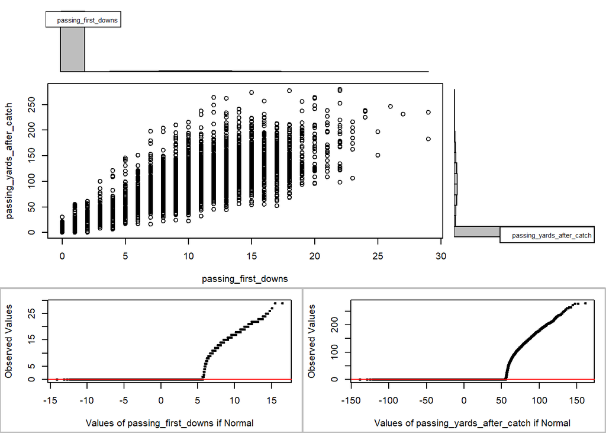

```
## Association between passing_first_downs (numerical) and  passing_yards_after_catch (numerical)
##  using 27690 complete cases
```

```
## Classic approach (must check assumptions):
##                                 Value Approximate p-value
## Pearson's r                 0.9476806                   0
## Spearman's rank correlation 0.9820973                   0
##
## Tests of assumptions:
##  -matters for Classic approach
##  -can be overly strict, so use graphics and judgment if Pass is FALSE
##                                 Test pvalue  Pass
##                            Linearity      0 FALSE
##                         Equal Spread      0 FALSE
##                     Linearity+Spread      0 FALSE
##        Normality passing_first_downs      0 FALSE
##  Normality passing_yards_after_catch      0 FALSE
##                  Bivariate Normality     NA    NA
##
##
## Advice: If stream of points is well described by an ellipse, use Pearson's r.
## Otherwise, as long as stream is monotonic, use Spearman's rank correlation
## or try logs, e.g. associate( log10(y)~log10(x) )
```

```r
assoc_yac_fd
```

[output not shown]

[output cut: 327 more lines]

[output not shown]

**Interpretation:** A strong positive correlation would suggest that quarterbacks whose receivers gain more yards after catch are more likely to sustain drives by converting first downs.

📊 Visualization:

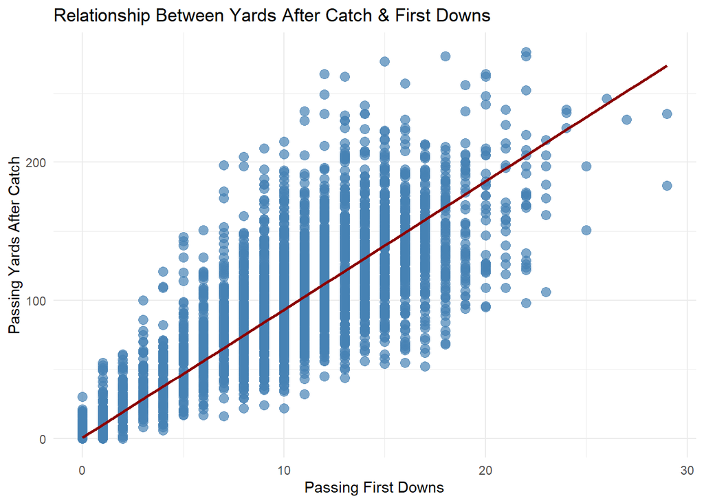

```r
ggplot(stats, aes(x = passing_first_downs, y = passing_yards_after_catch)) +
  geom_point(color = "steelblue", alpha = 0.7, size = 3) +
  geom_smooth(method = "lm", color = "darkred", fill = "pink", se = TRUE) +
  theme_minimal() +
  labs(title = "Relationship Between Yards After Catch & First Downs",
       x = "Passing First Downs",
       y = "Passing Yards After Catch")
```

### 2. Passing Attempts vs Interceptions

```r
# Spearman correlation test (association)
assoc_att_int <- associate(interceptions ~ attempts, data = stats)
```

```
## You have 27690 observations.  This may take a while.
## If you are sure you want to continue, type y then enter/return
```

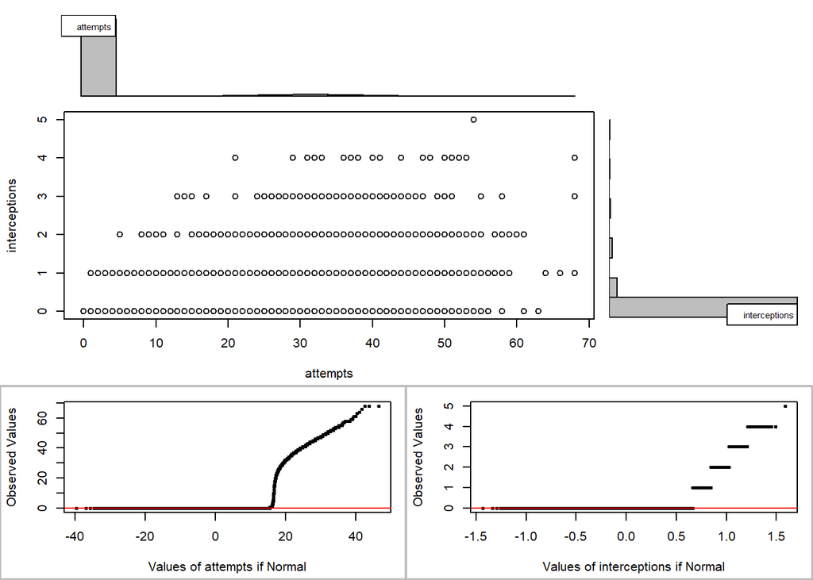

```
## Association between attempts (numerical) and  interceptions (numerical)
##  using 27690 complete cases
```

```
## Classic approach (must check assumptions):
##                                 Value Approximate p-value
## Pearson's r                 0.6336216                   0
## Spearman's rank correlation 0.6607126                   0
##
## Tests of assumptions:
##  -matters for Classic approach
##  -can be overly strict, so use graphics and judgment if Pass is FALSE
##                     Test        pvalue  Pass
##                Linearity 6.787006e-110 FALSE
##             Equal Spread  0.000000e+00 FALSE
##         Linearity+Spread  0.000000e+00 FALSE
##       Normality attempts  0.000000e+00 FALSE
##  Normality interceptions  0.000000e+00 FALSE
##      Bivariate Normality            NA    NA
##
##
## Advice: If stream of points is well described by an ellipse, use Pearson's r.
## Otherwise, as long as stream is monotonic, use Spearman's rank correlation
## or try logs, e.g. associate( log10(y)~log10(x) )
```

```r
assoc_att_int
```

[output not shown]

[output cut: 330 more lines]

[output not shown]

**Interpretation:** A positive correlation would indicate that quarterbacks with more passing attempts also throw more interceptions, likely reflecting game scripts or riskier passing strategies.

📊 Visualization:

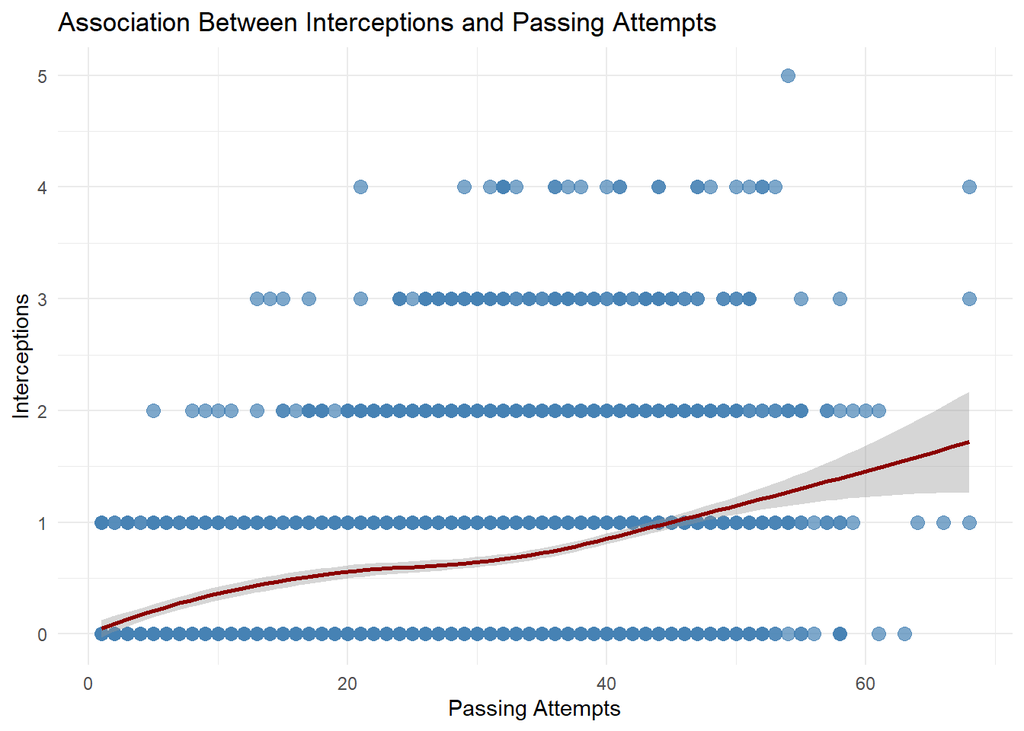

```r
# Clean data to remove missing values
cleaned_stats <- stats %>%
  filter(!is.na(attempts), !is.na(interceptions),
         is.finite(attempts), is.finite(interceptions),
         attempts > 0, interceptions >= 0)

ggplot(cleaned_stats, aes(x = attempts, y = interceptions)) +
  geom_point(color = "steelblue", alpha = 0.7, size = 3) +
  geom_smooth(method = "loess", color = "darkred", se = TRUE) +
  theme_minimal() +
  labs(title = "Association Between Interceptions and Passing Attempts",
       x = "Passing Attempts",
       y = "Interceptions")
```

# 📊 Distribution of Passing Yards (QBs Only)

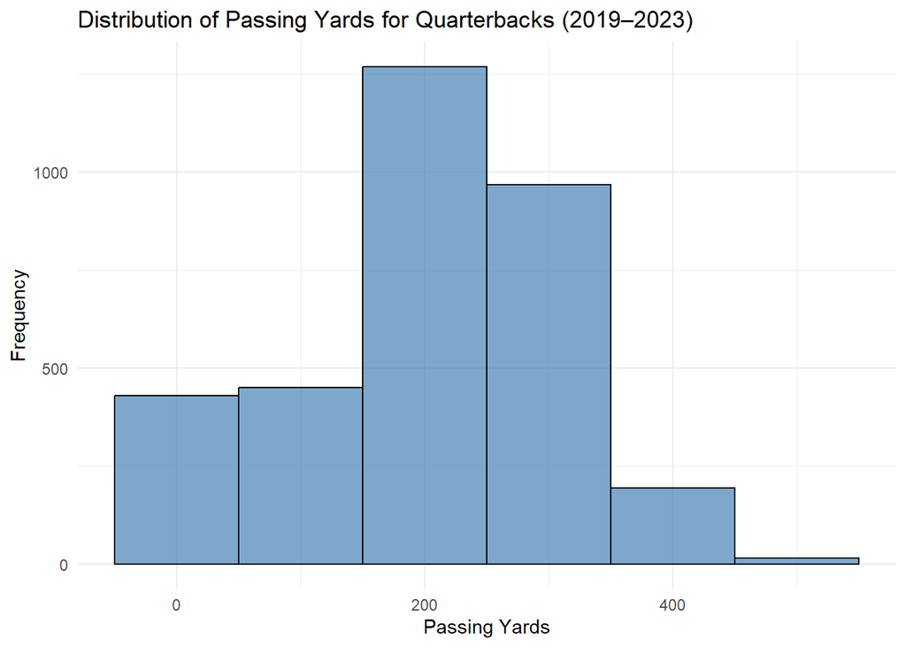

```r
qb_stats <- stats %>% filter(position == "QB")

ggplot(qb_stats, aes(x = passing_yards)) +
  geom_histogram(binwidth = 100, fill = "steelblue", color = "black", alpha = 0.7) +
  labs(title = "Distribution of Passing Yards for Quarterbacks (2019–2023)",
       x = "Passing Yards", y = "Frequency") +
  theme_minimal()
```

# 📋 Summary Statistics

```r
summary_table <- stats %>%
  select(passing_yards_after_catch, passing_first_downs, interceptions, attempts)

summary(summary_table)
```

```
##  passing_yards_after_catch passing_first_downs interceptions
##  Min.   :  0.00            Min.   : 0.000      Min.   :0.00000
##  1st Qu.:  0.00            1st Qu.: 0.000      1st Qu.:0.00000
##  Median :  0.00            Median : 0.000      Median :0.00000
##  Mean   : 11.48            Mean   : 1.188      Mean   :0.07877
##  3rd Qu.:  0.00            3rd Qu.: 0.000      3rd Qu.:0.00000
##  Max.   :280.00            Max.   :29.000      Max.   :5.00000
##     attempts
##  Min.   : 0.000
##  1st Qu.: 0.000
##  Median : 0.000
##  Mean   : 3.447
##  3rd Qu.: 0.000
##  Max.   :68.000
```

# 🏟️ Football Insights

- **YAC vs First Downs:** Shows how important ball placement and receiver ability are for sustaining drives.
- **Attempts vs Interceptions:** Demonstrates the tradeoff between high passing volume and turnover risk.
- **QB Passing Yards Distribution:** Confirms variation in passing production across quarterbacks.

# 🚀 Next Steps

- Extend analysis to include **completion percentage, touchdowns, and sack rate**.
- Build predictive models to forecast QB efficiency based on these features.
- Compare rookie vs veteran quarterbacks.

# 👤 Author

Andrew Gentilcore — Senior at the University of Tennessee, Knoxville  
Focus: **NFL & sports analytics, regression modeling, and data-driven football insights**